# Bayesian modeling and prediction for movies

## Setup

### Load packages

```r
library(ggplot2)
library(dplyr)
library(statsr)
library(BAS)
```

### Load data

```r
load("movies.Rdata")
```

## Part 1: Data

Data collection: The data consists of 651 randomly selected movies which are also available from Rotten Tomatoes and IMDB. The 32 variables are specific parameters of the movies and people’s opinion in the movies. source of bias: There could be possible source of bias when choosing the movies which are available on Rotten Tomatoes and IMDB only. In addition, the bias on people’s opinion is also possible

Generalization: Since random sampling was used with a reasonably large number of movies, the data does capture generalization.

Causation: This data is a result of observational study, there was no explicit random assignment. Hence, there is no causation in the data.

## Part 2: Data manipulation

Creating new variables using the mutate function.

```r
movies <- movies %>%
  mutate(feature_film=ifelse(title_type == "Feature Film","yes","no")) %>%
  mutate(drama = ifelse(genre == "Drama", "yes", "no")) %>%
  mutate(mpaa_rating_R = ifelse(mpaa_rating == "R","yes","no")) %>%
  mutate(oscar_season = ifelse((thtr_rel_month == 11)|(thtr_rel_month == 10)|(thtr_rel_month == 12),"yes","no")) %>%
  mutate(summer_season = ifelse((thtr_rel_month == 5)|(thtr_rel_month == 6)|(thtr_rel_month == 7)|(thtr_rel_month == 8),"yes","no"))
```

## Part 3: Exploratory data analysis

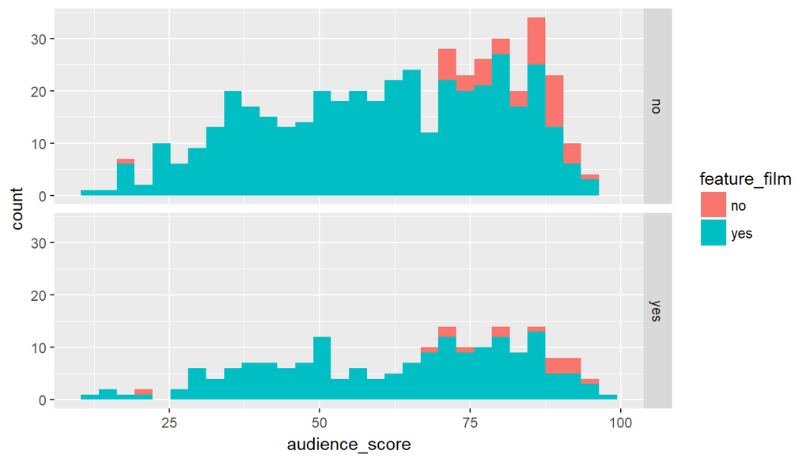

```r
ggplot(data = movies, mapping = aes(x = audience_score, fill = feature_film)) + geom_histogram() + facet_grid(oscar_season ~.)
```

Here, we show a feature film dependent histogram of audience score. It seems that no matter in which oscar season and feature film they are, the audience score follows the same tendency.

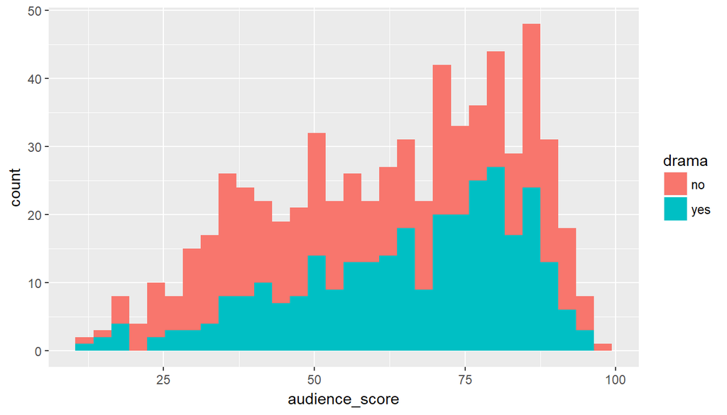

```r
ggplot(data = movies, mapping = aes(x = audience_score, fill = drama)) + geom_histogram()
```

The figure shows audience score by drama. The audience score histogram obviously dominates when drama is no.

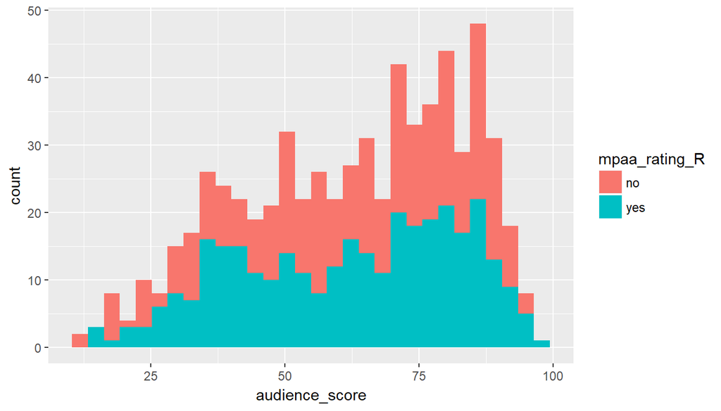

```r
ggplot(data = movies, mapping = aes(x = audience_score, fill = mpaa_rating_R)) + geom_histogram()
```

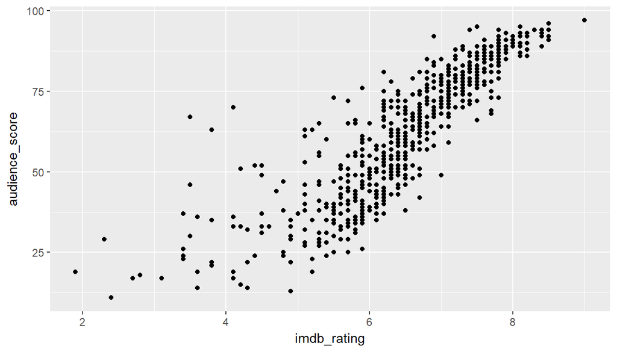

```r
ggplot(data = movies, mapping = aes(x = imdb_rating, y = audience_score)) + geom_point()
```

This is scatter plot of imdb_rating and audience_score. We expect a linear relationship between these two parameters, this could be easily fitted by a line.

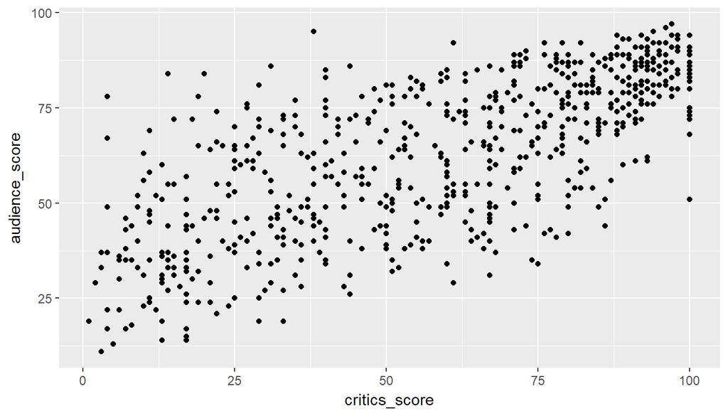

```r
ggplot(data = movies, mapping = aes(x = critics_score, y = audience_score)) + geom_point()
```

The plot of critics_score and audience_score are scattered, with a larger residuals.

```r
movies %>%
  summarise(mean_score=mean(audience_score),median_score=median(audience_score),sd_score=sd(audience_score),max_score=max(audience_score),min_score=min(audience_score))
```

```
## # A tibble: 1 x 5
##   mean_score median_score sd_score max_score min_score
##        <dbl>        <dbl>    <dbl>     <dbl>     <dbl>
## 1       62.4          65.     20.2       97.       11.
```

EDA of the audience score, this quality is important as a response variable with mean 62.4 and standard deviation 20.2.

```r
movies %>%
  summarise(mean_critics=mean(critics_score),median_critics=median(critics_score),sd_critics=sd(critics_score),max_critics=max(critics_score),min_critics=min(critics_score))
```

```
## # A tibble: 1 x 5
##   mean_critics median_critics sd_critics max_critics min_critics
##          <dbl>          <dbl>      <dbl>       <dbl>       <dbl>
## 1         57.7            61.       28.4        100.          1.
```

Results for EDA of critics score.

```r
movies %>%
  summarise(mean_imdb=mean(imdb_rating),median_imdb=median(imdb_rating),sd_imdb=sd(imdb_rating),max_imdb=max(imdb_rating),min_imdb=min(imdb_rating))
```

```
## # A tibble: 1 x 5
##   mean_imdb median_imdb sd_imdb max_imdb min_imdb
##       <dbl>       <dbl>   <dbl>    <dbl>    <dbl>
## 1      6.49        6.60    1.08       9.     1.90
```

EDA for imdb rating.

```r
movies %>%
  group_by(feature_film, drama,mpaa_rating_R) %>%
  summarise(count = n())
```

```
## # A tibble: 8 x 4
## # Groups:   feature_film, drama [?]
##   feature_film drama mpaa_rating_R count
##   <chr>        <chr> <chr>         <int>
## 1 no           no    no               46
## 2 no           no    yes              10
## 3 no           yes   no                2
## 4 no           yes   yes               2
## 5 yes          no    no              150
## 6 yes          no    yes             140
## 7 yes          yes   no              124
## 8 yes          yes   yes             177
```

Summary statistics of movies by feature film, drama and mpaa_rating_R.

## Part 4: Modeling

Bayesan model averaging:

```r
movies_no_na = na.omit(movies)
bma_movies = bas.lm(audience_score ~ feature_film + drama+runtime+mpaa_rating_R+thtr_rel_year+oscar_season+summer_season+imdb_rating+imdb_num_votes+critics_score+best_pic_nom+best_pic_win+best_actor_win+best_actress_win+best_dir_win+top200_box, data=movies_no_na,prior = "BIC", modelprior = uniform())
bma_movies
```

```
##
## Call:
## bas.lm(formula = audience_score ~ feature_film + drama + runtime +
##     mpaa_rating_R + thtr_rel_year + oscar_season + summer_season +
##     imdb_rating + imdb_num_votes + critics_score + best_pic_nom +
##     best_pic_win + best_actor_win + best_actress_win + best_dir_win +
##     top200_box, data = movies_no_na, prior = "BIC", modelprior = uniform())
##
##
##  Marginal Posterior Inclusion Probabilities:
##           Intercept      feature_filmyes             dramayes
##             1.00000              0.05876              0.04509
##             runtime     mpaa_rating_Ryes        thtr_rel_year
##             0.51400              0.16498              0.08089
##     oscar_seasonyes     summer_seasonyes          imdb_rating
##             0.06526              0.07935              1.00000
##      imdb_num_votes        critics_score      best_pic_nomyes
##             0.06242              0.92016              0.13201
##     best_pic_winyes    best_actor_winyes  best_actress_winyes
##             0.04077              0.11565              0.14770
##     best_dir_winyes        top200_boxyes
##             0.06701              0.04876
```

```r
summary(bma_movies)
```

```
##                     P(B != 0 | Y)    model 1       model 2       model 3
## Intercept              1.00000000     1.0000     1.0000000     1.0000000
## feature_filmyes        0.05876309     0.0000     0.0000000     0.0000000
## dramayes               0.04508592     0.0000     0.0000000     0.0000000
## runtime                0.51399873     1.0000     0.0000000     0.0000000
## mpaa_rating_Ryes       0.16498090     0.0000     0.0000000     0.0000000
## thtr_rel_year          0.08088668     0.0000     0.0000000     0.0000000
## oscar_seasonyes        0.06525993     0.0000     0.0000000     0.0000000
## summer_seasonyes       0.07935408     0.0000     0.0000000     0.0000000
## imdb_rating            1.00000000     1.0000     1.0000000     1.0000000
## imdb_num_votes         0.06242230     0.0000     0.0000000     0.0000000
## critics_score          0.92015573     1.0000     1.0000000     1.0000000
## best_pic_nomyes        0.13200908     0.0000     0.0000000     0.0000000
## best_pic_winyes        0.04076727     0.0000     0.0000000     0.0000000
## best_actor_winyes      0.11565473     0.0000     0.0000000     0.0000000
## best_actress_winyes    0.14770126     0.0000     0.0000000     1.0000000
## best_dir_winyes        0.06701259     0.0000     0.0000000     0.0000000
## top200_boxyes          0.04875994     0.0000     0.0000000     0.0000000
## BF                             NA     1.0000     0.8715404     0.2048238
## PostProbs                      NA     0.1558     0.1358000     0.0319000
## R2                             NA     0.7483     0.7455000     0.7470000
## dim                            NA     4.0000     3.0000000     4.0000000
## logmarg                        NA -3434.7520 -3434.8894481 -3436.3375603
##                           model 4       model 5
## Intercept               1.0000000     1.0000000
## feature_filmyes         0.0000000     0.0000000
## dramayes                0.0000000     0.0000000
## runtime                 1.0000000     1.0000000
## mpaa_rating_Ryes        1.0000000     0.0000000
## thtr_rel_year           0.0000000     0.0000000
## oscar_seasonyes         0.0000000     0.0000000
## summer_seasonyes        0.0000000     0.0000000
## imdb_rating             1.0000000     1.0000000
## imdb_num_votes          0.0000000     0.0000000
## critics_score           1.0000000     1.0000000
## best_pic_nomyes         0.0000000     1.0000000
## best_pic_winyes         0.0000000     0.0000000
## best_actor_winyes       0.0000000     0.0000000
## best_actress_winyes     0.0000000     0.0000000
## best_dir_winyes         0.0000000     0.0000000
## top200_boxyes           0.0000000     0.0000000
## BF                      0.2039916     0.1851908
## PostProbs               0.0318000     0.0289000
## R2                      0.7496000     0.7495000
## dim                     5.0000000     5.0000000
## logmarg             -3436.3416317 -3436.4383237
```

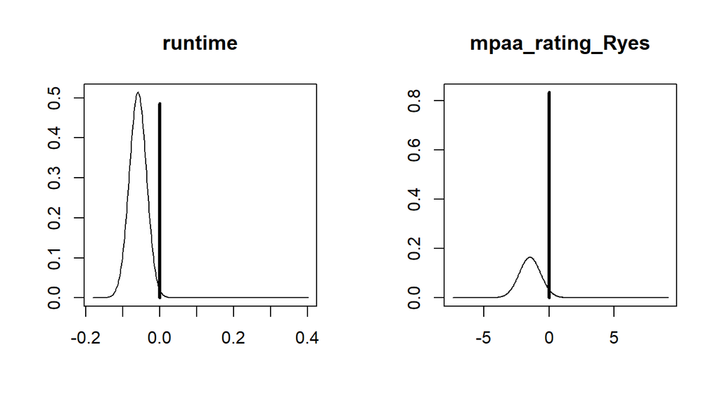

```r
par(mfrow = c(1,2))
coef_movies = coefficients(bma_movies)
plot(coef_movies, subset = c(4,5), ask=FALSE)
```

Plot shows coefficient of BMA model for runtime and mpaa_rating_R. We also probide 95% credible intervals for these coefficients:

```r
confint(coef_movies)
```

```
##                              2.5%        97.5%          beta
## Intercept            6.141669e+01 6.302287e+01  6.221002e+01
## feature_filmyes     -1.000434e+00 0.000000e+00 -9.162435e-02
## dramayes             0.000000e+00 0.000000e+00  1.956484e-02
## runtime             -8.971295e-02 0.000000e+00 -3.042190e-02
## mpaa_rating_Ryes    -2.004956e+00 6.288931e-03 -2.409288e-01
## thtr_rel_year       -4.052840e-02 0.000000e+00 -3.878883e-03
## oscar_seasonyes     -6.577237e-01 0.000000e+00 -6.293171e-02
## summer_seasonyes     0.000000e+00 9.905220e-01  8.660919e-02
## imdb_rating          1.360266e+01 1.654338e+01  1.490680e+01
## imdb_num_votes      -2.534270e-07 1.972595e-06  2.466254e-07
## critics_score        0.000000e+00 1.122687e-01  6.951964e-02
## best_pic_nomyes      0.000000e+00 5.223817e+00  5.130600e-01
## best_pic_winyes      0.000000e+00 0.000000e+00 -6.383140e-03
## best_actor_winyes   -2.207554e+00 1.249477e-03 -2.123363e-01
## best_actress_winyes -2.909514e+00 2.938098e-02 -3.323225e-01
## best_dir_winyes     -1.066502e+00 7.850088e-02 -1.188402e-01
## top200_boxyes        0.000000e+00 0.000000e+00  8.972019e-02
## attr(,"Probability")
## [1] 0.95
## attr(,"class")
## [1] "confint.bas"
```

Use a Zellner-Siow null prior for the coefficients and a Beta-Binomial (1,1) prior for the models

```r
movies_no_na = na.omit(movies)
naive_movies = bas.lm(audience_score ~ feature_film + drama+runtime+mpaa_rating_R+thtr_rel_year+oscar_season+summer_season+imdb_rating+imdb_num_votes+critics_score+best_pic_nom+best_pic_win+best_actor_win+best_actress_win+best_dir_win+top200_box, data=movies_no_na,
                   prior = "ZS-null",
                   modelprior = beta.binomial(1,1))
summary(naive_movies)
```

```
##                     P(B != 0 | Y)     model 1      model 2  model 3
## Intercept             1.000000000   1.0000000   1.00000000   1.0000
## feature_filmyes       0.015872612   0.0000000   0.00000000   0.0000
## dramayes              0.009396506   0.0000000   0.00000000   0.0000
## runtime               0.180993785   0.0000000   0.00000000   1.0000
## mpaa_rating_Ryes      0.039543829   0.0000000   0.00000000   0.0000
## thtr_rel_year         0.017253650   0.0000000   0.00000000   0.0000
## oscar_seasonyes       0.017434416   0.0000000   0.00000000   0.0000
## summer_seasonyes      0.020451389   0.0000000   0.00000000   0.0000
## imdb_rating           1.000000000   1.0000000   1.00000000   1.0000
## imdb_num_votes        0.011732318   0.0000000   0.00000000   0.0000
## critics_score         0.657640388   1.0000000   0.00000000   1.0000
## best_pic_nomyes       0.024529779   0.0000000   0.00000000   0.0000
## best_pic_winyes       0.008887072   0.0000000   0.00000000   0.0000
## best_actor_winyes     0.032978988   0.0000000   0.00000000   0.0000
## best_actress_winyes   0.039435550   0.0000000   0.00000000   0.0000
## best_dir_winyes       0.016671563   0.0000000   0.00000000   0.0000
## top200_boxyes         0.010646278   0.0000000   0.00000000   0.0000
## BF                             NA   0.9928814   0.08035048   1.0000
## PostProbs                      NA   0.4073000   0.24720000   0.0879
## R2                             NA   0.7455000   0.74050000   0.7483
## dim                            NA   3.0000000   2.00000000   4.0000
## logmarg                        NA 413.8748206 411.36060745 413.8820
##                          model 4     model 5
## Intercept             1.00000000   1.0000000
## feature_filmyes       0.00000000   0.0000000
## dramayes              0.00000000   0.0000000
## runtime               1.00000000   0.0000000
## mpaa_rating_Ryes      0.00000000   0.0000000
## thtr_rel_year         0.00000000   0.0000000
## oscar_seasonyes       0.00000000   0.0000000
## summer_seasonyes      0.00000000   0.0000000
## imdb_rating           1.00000000   1.0000000
## imdb_num_votes        0.00000000   0.0000000
## critics_score         0.00000000   1.0000000
## best_pic_nomyes       0.00000000   0.0000000
## best_pic_winyes       0.00000000   0.0000000
## best_actor_winyes     0.00000000   0.0000000
## best_actress_winyes   0.00000000   1.0000000
## best_dir_winyes       0.00000000   0.0000000
## top200_boxyes         0.00000000   0.0000000
## BF                    0.09635143   0.2074592
## PostProbs             0.03950000   0.0182000
## R2                    0.74360000   0.7470000
## dim                   3.00000000   4.0000000
## logmarg             411.54221157 412.3091439
```

# Training the data

Similar to the codes in suplementary materials. We train the data using four different predictors and compare the efficiency of them:

```r
set.seed(42)

movies_no_na = na.omit(movies)

n = nrow(movies_no_na)
n_cv = 50
ape = matrix(NA, ncol=4, nrow=n_cv)
colnames(ape) = c("BMA", "BPM", "HPM", "MPM")

for (i in 1:n_cv) {
  train = sample(1:n, size=round(.90*n), replace=FALSE)
  lmovies_train = movies_no_na[train,]
  lmovies_test = movies_no_na[-train,] # drop specific row in R

  bma_train_movies = bas.lm(audience_score ~ feature_film + drama+runtime+mpaa_rating_R+thtr_rel_year+oscar_season+summer_season+imdb_rating+imdb_num_votes+critics_score+best_pic_nom+best_pic_win+best_actor_win+best_actress_win+best_dir_win+top200_box, data=lmovies_train, prior="BIC", modelprior=uniform(), initprobs="eplogp")
  yhat_bma = predict(bma_train_movies, lmovies_test, estimator="BMA")$fit
  yhat_hpm = predict(bma_train_movies, lmovies_test, estimator="HPM")$fit
  yhat_mpm = predict(bma_train_movies, lmovies_test, estimator="MPM")$fit
  yhat_bpm = predict(bma_train_movies, lmovies_test, estimator="BPM")$fit
  ape[i, "BMA"] = cv.summary.bas(yhat_bma, lmovies_test$audience_score)
  ape[i, "BPM"] = cv.summary.bas(yhat_bpm, lmovies_test$audience_score)
  ape[i, "HPM"] = cv.summary.bas(yhat_hpm, lmovies_test$audience_score)
  ape[i, "MPM"] = cv.summary.bas(yhat_mpm, lmovies_test$audience_score)
}
```

Checking sensitivity the predictions are to the choice of estimator: We can see BMA is the best estimator.

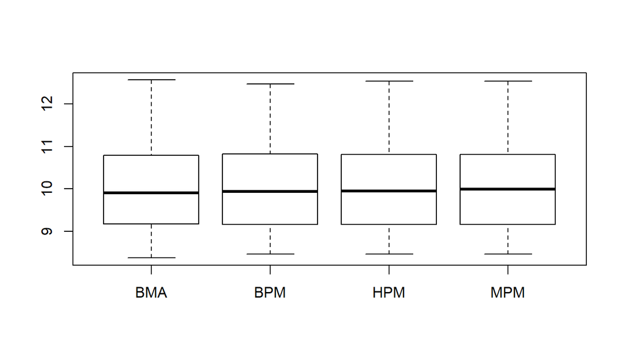

```r
boxplot(ape)
```

```r
apply(ape, 2, mean)
```

```
##      BMA      BPM      HPM      MPM
## 10.12121 10.14694 10.14616 10.16181
```

Here we compare the mean of all four type of predictors.

## Part 5: Prediction

Here I pick a movie from 2016 (a new movie that is not in the sample)

```r
newmovie <- data.frame(feature_film ="yes",drama = "yes", runtime = 120, mpaa_rating_R = "yes", thtr_rel_year = 2016, oscar_season = "yes", summer_season = "no", imdb_rating = 5.5, imdb_num_votes = 1000, critics_score = 96, best_pic_nom = "no", best_pic_win = "no", best_actor_win = "no", best_actress_win = "no", best_dir_win = "no", top200_box = "no")
```

We take the data for this movie randomly, and it does not exist in the data. However, we attempted to choose all the parameters in the data in an acceptable range, i.e between min and max of all parameters of interest.

Predict with confident level:

```r
#predict(bma_movies, newmovie, interval = "prediction", level = 0.95)
newmovies.pred <- predict(bma_movies, newdata=newmovie, estimator="BMA", se.fit=TRUE, interval="predict")
newmovies.pred$Ybma
```

```
##          [,1]
## [1,] 49.57648
```

Hence, we predict that newmovie hat an expected value of 49.57648